# P4330_Assignment01

Ken Suzuki

2023-10-21

List of functions

```r
library(flexplot) # Visualization for mediation linear model
library(MBESS)
library(mice)
library(tidyverse)
library(GGally)
library(mediation)
```

### Outline:

The dataset for this assignment comes from a study by Dr. Bob Altemeyer from the University of Manitoba. Dr. Altemeyer primarily studied right wing authoritarianism’ (RWA, personality trait of someone who is highly submissive to their authority figures, acts aggressively in the name of said authorities, and is conformist in thought and behavior).

#### Variables:

- **rwas**: Level of Submissiveness to Authorities. RWA scale, average score across 22 seven-point Likert items,
- **age**:
- **education**:
  1. less than high school
  2. high school
  3. college/university)
  4. graduate/professional degree
- **TIPI10**: Level of conventional/uncreative personality, 1-7 Likert scale
- **gender**:

### Loading data and Verification:

```r
# Load the data
master_d <- read.csv ("~/Desktop/P4330/P4330 R code/P4330_Assignment01/rwas_altemeyer.csv")
str(master_d)
```

```
## 'data.frame':    55 obs. of  5 variables:
##  $ age      : int  36 19 25 NA 26 18 17 16 31 17 ...
##  $ TIPI10   : int  5 1 3 1 2 1 2 2 3 4 ...
##  $ education: int  3 2 4 3 3 2 1 2 3 2 ...
##  $ gender   : chr  "male" "female" "male" "female" ...
##  $ rwas     : num  5.5 4.5 5 5.5 4.4 5 4.7 5.2 4.5 4.6 ...
```

```r
head(master_d)
```

```
##   age TIPI10 education gender rwas
## 1  36      5         3   male  5.5
## 2  19      1         2 female  4.5
## 3  25      3         4   male  5.0
## 4  NA      1         3 female  5.5
## 5  26      2         3   male  4.4
## 6  18      1         2   male  5.0
```

### Part A

For this question we are interested in predicting rwas from age, education, TIPI10, and gender. *We are going to treat education as a factor in this question (with “high school” education as the reference category).*

*Due to some missing data, we will use multiple imputation (4 imputed datasets) for the analysis. You can skip testing assumptions for this analysis.

Initial Data Processing

```r
# Change education to factor and assign each level a name
d <- master_d %>%
  mutate(education = factor(education,
                            levels = c(1, 2, 3, 4),
                            labels = c(": Less than high school", ": High school",
                                       ": Coll/Univ", ": Grad/Prof_Dg")))

summary(d)
```

```
##       age            TIPI10                        education
##  Min.   :13.00   Min.   :1.000   : Less than high school: 9
##  1st Qu.:17.00   1st Qu.:1.000   : High school          :28
##  Median :21.50   Median :2.000   : Coll/Univ            :11
##  Mean   :26.92   Mean   :2.808   : Grad/Prof_Dg         : 7
##  3rd Qu.:34.50   3rd Qu.:4.000
##  Max.   :58.00   Max.   :7.000
##  NA's   :3       NA's   :3
##     gender               rwas
##  Length:55          Min.   :4.400
##  Class :character   1st Qu.:4.600
##  Mode  :character   Median :4.900
##                     Mean   :5.029
##                     3rd Qu.:5.450
##                     Max.   :6.300
##
```

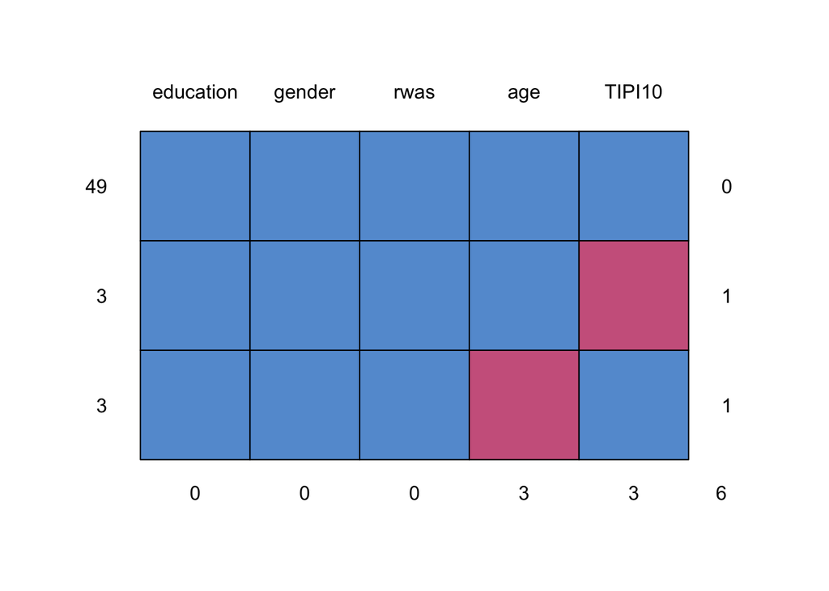

```
##    education gender rwas age TIPI10
## 49         1      1    1   1      1 0
## 3          1      1    1   1      0 1
## 3          1      1    1   0      1 1
##            0      0    0   3      3 6
```

```r
# Check for missingness in the dataset
md.pattern(d)
```

#### Conduct Multiple Imputation

```r
# Setting seed so that the imputed values don't change while rerunning the code for checking and fixing (I noticed that every time I "Knit" my imputation values change, leading to descrepancies between Imputed Linear Model summary and my already written report)
set.seed(123)

#Impute data using Multiple Imputation
Mul_Imp_10 <- mice(d, method = "norm.nob", m = 10, printFlag = FALSE)
d_Mul_Imp_10 <- complete(Mul_Imp_10)

# Confirm the imputation and ensure no NAs.
summary(d_Mul_Imp_10)
```

```
##       age            TIPI10                         education
##  Min.   :13.00   Min.   :-1.239   : Less than high school: 9
##  1st Qu.:17.00   1st Qu.: 1.000   : High school          :28
##  Median :23.00   Median : 2.000   : Coll/Univ            :11
##  Mean   :27.15   Mean   : 2.794   : Grad/Prof_Dg         : 7
##  3rd Qu.:33.59   3rd Qu.: 4.000
##  Max.   :58.00   Max.   : 7.000
##     gender               rwas
##  Length:55          Min.   :4.400
##  Class :character   1st Qu.:4.600
##  Mode  :character   Median :4.900
##                     Mean   :5.029
##                     3rd Qu.:5.450
##                     Max.   :6.300
```

#### Question 1 and 2

```r
names(d)
```

```
## [1] "age"       "TIPI10"    "education" "gender"    "rwas"
```

```r
# Build an Imputated model
Mul_Imp_m <- lm(rwas ~ age + education + TIPI10 + gender, data = d_Mul_Imp_10)
summary(Mul_Imp_m)
```

```
##
## Call:
## lm(formula = rwas ~ age + education + TIPI10 + gender, data = d_Mul_Imp_10)
##
## Residuals:
##     Min      1Q  Median      3Q     Max
## -0.8765 -0.2796 -0.0451  0.1995  1.0529
##
## Coefficients:
##                          Estimate Std. Error t value Pr(>|t|)
## (Intercept)              5.004262   0.208481  24.003  < 2e-16 ***
## age                     -0.002278   0.005329  -0.428  0.67090
## education: High school  -0.327150   0.176765  -1.851  0.07036 .
## education: Coll/Univ    -0.480427   0.215546  -2.229  0.03054 *
## education: Grad/Prof_Dg -0.666067   0.239949  -2.776  0.00783 **
## TIPI10                   0.100649   0.033366   3.017  0.00408 **
## gendermale               0.205109   0.141409   1.450  0.15343
## ---
## Signif. codes:  0 '***' 0.001 '**' 0.01 '*' 0.05 '.' 0.1 ' ' 1
##
## Residual standard error: 0.4342 on 48 degrees of freedom
## Multiple R-squared:  0.3651, Adjusted R-squared:  0.2857
## F-statistic:   4.6 on 6 and 48 DF,  p-value: 0.0009165
```

```r
confint(Mul_Imp_m)
```

```
##                               2.5 %       97.5 %
## (Intercept)              4.58508284  5.423442048
## age                     -0.01299365  0.008436726
## education: High school  -0.68255932  0.028258432
## education: Coll/Univ    -0.91381227 -0.047042675
## education: Grad/Prof_Dg -1.14851765 -0.183617109
## TIPI10                   0.03356233  0.167734801
## gendermale              -0.07921240  0.489431091
```

#### Interpretation

##### Age

The coeffient of estimated for age on RWA score indicates that for every one-year increase in age, there is an estimated decrease of 0.002278 units in RWA score holding all other variables constant. However, the p-value (0.67090) is larger than the threshold of a = 0.10, implying that age is not statistically significant for predicting RWA scores.

##### Education: High School

The RWA value for people with high school education is estimated at -0.327150, on average, compared to the females with less than high school education. This value indicates those who have high school education are estimated to have less RWA scores compared to the base population when all other variables are held constant. The corresponding p value is p=0.07036, and based on a = 0.1, the null hypothesis is rejected and high school education is statistically significant for predicting RWA. In this case, a unit-increase indicates the target individuals have high school educations.

##### Education: College/University

The RWA value for people with college or university education is estimated, on average, at -0.480427 compared to the base population when all other variables are controlled for. Based on the a = 0.1 threshold, the corresponding p value = 0.03054 is statistically significant. Therefore, the null hypothesis is rejected and supports the alternative hypothesis that having college and/or university education have the statistically significant effect on RWA score.

##### Education: Grad/Prof_Dg

Furthermore, the RWA value for people with Graduate or Professional degrees is estimated at -0.666067, on average, compared to the base population when all other variables are held constant. The corresponding low p value of 0.00783 indicates that higher education such as graduate degree or above is a statistically significant predictor for lower RWA scores compared to those who are female with less than a high school education.

##### TIPI10

The variable **TIPI10** is also statistically significant (p = 0.00408) in predicting one’s RWA score based on a = 0.10. This very small value indicates that for every one-unit increase in TIPI10, the RWA is estimated to increase by 0.100649 unit, on average when all other variables are held constant.

##### Gender(Male)

In the sample, males have an average RWA score that is 0.205109 units higher than females with an education level less than high school. However, this difference is not statistically significant, as indicated by a p-value of 0.15343, which exceeds the threshold, a = 0.10. Consequently, we are unable to reject the null hypothesis, concluding that the higher unit scores for males are not statistically significant.

##### 3) Recalculate the standard error for the “*age”* effect using Eqs 1:3 from Baraldi & Enders.

From the article pp.17-18 by Baraldi & Enders

To calculate the SE = √W+B+B/m, where:

- W = Sum of SE²t / m
- B = Sum[Predicted parameter estimate (Estimate of age) - mean of parameter (Mean of age)]² / m-1

```r
# Aquire each imputed data set and get SE for 10 different imputation
Mul_Imp_10 <- mice(d, method = "norm.nob", m = 10, printFlag = FALSE)
# Create empty vectors to store the standard error and estimates
pooled_se <- vector("numeric", length = 10)
pooled_estimate <- vector("numeric", length = 10)

# Loop through the 10 imputed datasets
for (i in 1:10) {
  # Complete the imputed dataset
  dati <- complete(Mul_Imp_10, action = i)

  # Run the linear model and summary
  dati_lm <- lm(rwas ~ age + education + TIPI10 + gender, data = dati)
  dati_summary <- summary(dati_lm)

  # Extract standard error and estimate for 'age'
  pooled_se[i] <- dati_summary$coefficients[,'Std. Error']['age']
  pooled_estimate[i] <- dati_summary$coefficients[,'Estimate']['age']
}

# Solve for W -> W = Sum of SE²t / m
W <- sum(pooled_se)/10

# Solve for Theta-hat
MeanTheta <- mean(pooled_estimate)

pooled_estimate
```

```
##  [1] -0.0019344952 -0.0002838454 -0.0045891127 -0.0035153700 -0.0037567881
##  [6] -0.0038797397 -0.0011823281 -0.0014276767 -0.0058293328 -0.0034012693
```

```r
# Enter each predicted theta value into the following equation and solve for B
B <- (-0.0019344952 - MeanTheta)^2 +
  (-0.0002838454 - MeanTheta)^2 +
  (-0.0045891127 - MeanTheta)^2 +
  (-0.0035153700 - MeanTheta)^2 +
  (-0.0037567881 - MeanTheta)^2 +
  (-0.0038797397 - MeanTheta)^2 +
  (-0.0011823281 - MeanTheta)^2 +
  (-0.0014276767 - MeanTheta)^2 +
  (-0.0058293328 - MeanTheta)^2 +
  (-0.0034012693 - MeanTheta)^2/(10-1)

# Obtain the Pooled Standard Error
P_SE <- sqrt(W + B + (B/10))

print(P_SE)
```

```
## [1] 0.0731343
```

##### 4) Interpret the magnitude of the gender effect (do your best… I now you are not RWA researchers).

In the sample, males have an average RWA score that is 0.205109 units higher than females with an education level less than high school. However, this difference is not statistically significant, as indicated by a p-value of 0.15343, which exceeds the threshold, a = 0.10. Consequently, we are unable to reject the null hypothesis, concluding that the higher unit scores for males are not statistically significant.

### Part B

For this part we are interested in whether education mediates the relationship between age and rwas. We are going to treat education as a continuous variable, and use stochastic regression imputation. Use bootstrapping for the analysis (1000 samples).

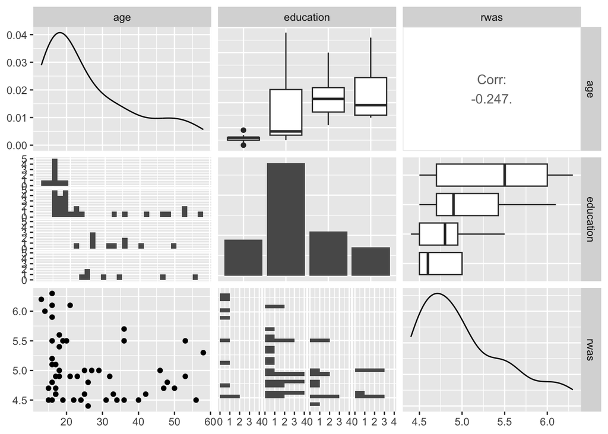

```r
# Check the relationships
d %>%
  dplyr::select(age, education, rwas) %>%
  GGally::ggpairs()
```

```r
# Set seed so Knitting won't change the values.
set.seed(123)

# Run Stochastic regression imputation (Multiple Imputatoin) x 1000
d_Sto_Imp <- mice(master_d, method = "norm.nob", m = 1, printFlag = FALSE)
Sto_Imp1 <- complete(d_Sto_Imp)

# Look at basic stats
summary(Sto_Imp1)
```

```
##       age            TIPI10        education        gender
##  Min.   :11.80   Min.   :1.000   Min.   :1.000   Length:55
##  1st Qu.:17.00   1st Qu.:1.000   1st Qu.:2.000   Class :character
##  Median :22.00   Median :2.000   Median :2.000   Mode  :character
##  Mean   :26.98   Mean   :2.854   Mean   :2.291
##  3rd Qu.:35.00   3rd Qu.:4.000   3rd Qu.:3.000
##  Max.   :58.00   Max.   :7.000   Max.   :4.000
##       rwas
##  Min.   :4.400
##  1st Qu.:4.600
##  Median :4.900
##  Mean   :5.029
##  3rd Qu.:5.450
##  Max.   :6.300
```

```r
summary(master_d)
```

```
##       age            TIPI10        education        gender
##  Min.   :13.00   Min.   :1.000   Min.   :1.000   Length:55
##  1st Qu.:17.00   1st Qu.:1.000   1st Qu.:2.000   Class :character
##  Median :21.50   Median :2.000   Median :2.000   Mode  :character
##  Mean   :26.92   Mean   :2.808   Mean   :2.291
##  3rd Qu.:34.50   3rd Qu.:4.000   3rd Qu.:3.000
##  Max.   :58.00   Max.   :7.000   Max.   :4.000
##  NA's   :3       NA's   :3
##       rwas
##  Min.   :4.400
##  1st Qu.:4.600
##  Median :4.900
##  Mean   :5.029
##  3rd Qu.:5.450
##  Max.   :6.300
##
```

```r
# Run a mediation model and see if education mediates the age and rwas
med_model <- lm(education ~ age, data = Sto_Imp1)
tot_model <- lm(rwas ~ age + education, data = Sto_Imp1)

# mediate
library(mediation)

res <- mediate(model.m = med_model,
               model.y = tot_model,
               treat = 'age',
               mediator = 'education',
               boot = TRUE,
               sims = 1000)

summary(res)
```

```
##
## Causal Mediation Analysis
##
## Nonparametric Bootstrap Confidence Intervals with the Percentile Method
##
##                Estimate 95% CI Lower 95% CI Upper p-value
## ACME           -0.00605     -0.01204         0.00   0.006 **
## ADE            -0.00325     -0.01196         0.00   0.448
## Total Effect   -0.00931     -0.02001         0.00   0.058 .
## Prop. Mediated  0.65055     -0.71854         2.61   0.064 .
## ---
## Signif. codes:  0 '***' 0.001 '**' 0.01 '*' 0.05 '.' 0.1 ' ' 1
##
## Sample Size Used: 55
##
##
## Simulations: 1000
```

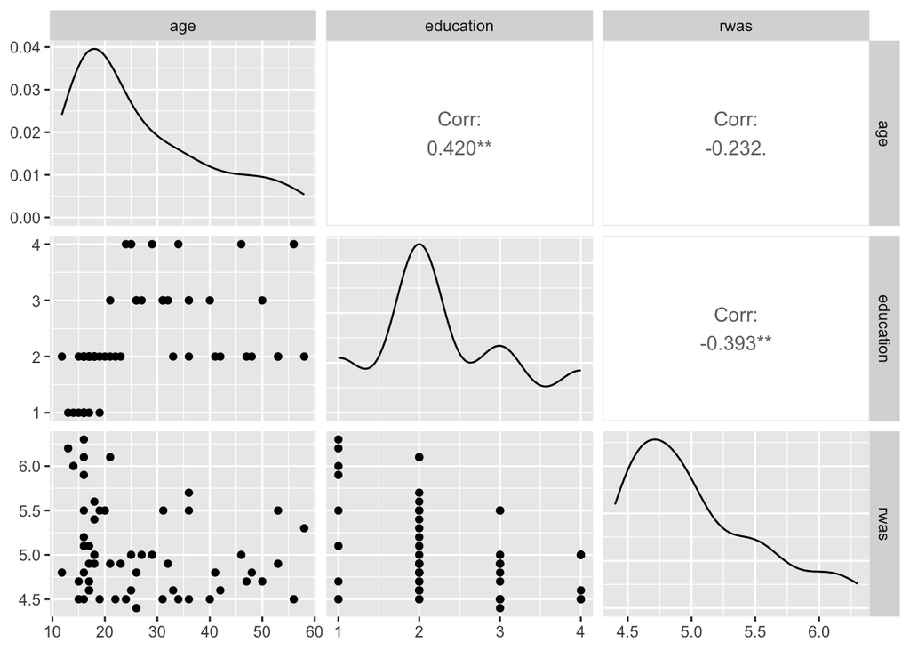

```r
# Check the relationship after imputation
Sto_Imp1 %>%
  dplyr::select(age, education, rwas) %>%
  GGally::ggpairs()
```

##### 1) Summarize the null hypothesis testing results for the indirect effect, using a = .01. You can use the p-value for this analysis.

P value for the Average Causal Mediation Effect (Indirect effect) is 0.006, which is statistically significant given that a = .01. Therefore, the null hypothesis – indirect effect is equal to zero – is rejected, and the alternative hypothsis -education mediates the relationship between age and rwas- is supported.

##### 2) Interpret the coefficient for the indirect effect.

The coefficient estimate of -0.00605 for the indirect effect indicates that, when mediated by Education, a one-year increase in age results in a reduction of the RWA score by 0.00605 units.

##### 3) Use effect size measures to discuss the magnitude of the indirect effect.

```r
# I have tried bootstrapping x1000 but took too long to complete, so I dialed it back to 50. Would this be a conventional practice? How do you determine what bootstrapping value is most reasonable (not costing too much computation power but not too small)?
upsilon(x = Sto_Imp1 $age,
        mediator = Sto_Imp1$education,
        dv = Sto_Imp1$rwas, B = 50)
```

```
## Bootstrapping may take several minutes
##
```

```
##               Estimate 95% ordinary LCL 95% ordinary UCL
## Upsilon     0.02276190     0.0037847189       0.10381370
## Adj Upsilon 0.01783161     0.0003613953       0.09255869
```

Because the confidence intervals do not include zero between the Lower Confidence Limit and the Upper Confidence Limit, the mediation effect is statistically significant.

In conclusion, people’s age has an indirect effect on RWA scores through its effect on Education.